# Diagnostic Tests & Screening

Adam La Caze

Semester 1, 2023

## Objectives

- Be able to describe and calculate the properties of a test for disease: sensitivity, specificity, positive predictive value, negative predictive value
- Be able to assess the usefulness of a diagnostic or screening test
- Be able to describe the common sources of bias when assessing a screening test

## Key concepts

- A negative result from a highly sensitive test helps to rule out presence of disease
- A positive result from a highly specific test helps to establish presence of disease
- The positive and negative predictive value of a test depend on the prevalence of disease in the population (beware the base rate fallacy)
- Determining the clinical utility of screening tests can be difficult (and subject to bias)

# Testing for disease

**Diagnostic tests**

are used to test for a particular disease in people **with** signs and/or symptoms of the disease

**Screening tests**

are used to test for a particular disease in people **without** signs or symptoms of the disease

There are many different ways to test for disease

- Measure a biomarker, e.g. HbA1c, troponin, INR, …
- Assess a clinical syndrome, e.g. depression scales
- Presence of absence of symptoms in clinical history
- …

## Key properties of a test

How does the test perform when assessed against the **gold standard** method for determining the presence or absence of disease?

**Sensitivity**

the proportion of people with disease who have a positive test result

**Specificity**

the proportion of people without disease who have a negative test result

**Positive predictive value**

the proportion of people with a positive test result who have the disease

**Negative predictive value**

the proportion of people with a negative test result who don’t have the disease

## Sensitivity and specificity

|  | Condition | No condition | Total |
| --- | --- | --- | --- |
| Test $+$ | $a$ | $b$ | $(a + b)$ |
| Test $-$ | $c$ | $d$ | $(c + d)$ |
| Total | $(a+c)$ | $(b+d)$ | $(a+b+c+d)$ |

Sensitivity ($Sn$)

$$Sn = \frac{a}{a + c}$$

Specificity ($Sp$)

$$Sp = \frac{d}{b + d}$$

## Positive and negative predictive value

|  | Condition | No condition | Total |
| --- | --- | --- | --- |
| Test $+$ | $a$ | $b$ | $(a + b)$ |
| Test $-$ | $c$ | $d$ | $(c + d)$ |
| Total | $(a+c)$ | $(b+d)$ | $(a+b+c+d)$ |

Positive predictive value  
($PPV$)

$$PPV = \frac{a}{a+b}$$

Negative predictive value  
($NPV$)

$$NPV = \frac{d}{c+d}$$

## Prevalence

$$P = \frac{a + c}{a + b + c +
d}$$

The prevalence of the condition in the population won’t affect sensitivity or specificity, but will have a large effect on positive and negative predictive value.

## Troponin

- Troponin is a biomarker of cardiac cell death; it is used to identify people who have experienced a myocardial infarction or more severe acute coronary syndrome
- A study recruits 1000 patients with symptoms of acute coronary syndrome
- All patients have a troponin level assessed at admission
- At the end of the study a cardiologist will review each participant’s clinical characteristics to determine whether they experienced a myocardial infarction
- The cardiologist judges 530 of the 1000 participants to have had a myocardial infarction
- Troponin was raised in 600 of the participants, the cardiologist assessed:
  - 100 participants who had an elevated troponin but not a myocardial infarction
  - 30 participants to have had a myocardial infarction despite a negative troponin

## Troponin testing characteristics (ACS population)

|  | Condition | No condition | Total |
| --- | --- | --- | --- |
| Test $+$ | $a$ | 100 | 600 |
| Test $-$ | 30 | $d$ | $(c + d)$ |
| Total | 530 | $(b+d)$ | 1000 |

|  | Condition | No condition | Total |
| --- | --- | --- | --- |
| Test $+$ | 500 | 100 | 600 |
| Test $-$ | 30 | 370 | 400 |
| Total | 530 | 470 | 1000 |

$$Sn = \frac{a}{a + c} = 500/530=
94\%$$

$$Sp = \frac{d}{b + d} = 370/470 =
79\%$$

|  | Condition | No condition | Total |
| --- | --- | --- | --- |
| Test $+$ | 500 | 100 | 600 |
| Test $-$ | 30 | 370 | 400 |
| Total | 530 | 470 | 1000 |

$$PPV = \frac{a}{a+b} = 500/600 =
83\%$$

$$NPV = \frac{d}{c+d} = 370/400 =
92\%$$

$$P = \frac{a + c}{a + b + c + d} =
530/1000 = 53\%$$

According to this study, testing troponin is sensitive and specific and has good positive and negative predictive value in this population.

## Calculating the properties of testing for troponin in an unselected population

- The positive and negative predictive value of a test depends on the **prevalence** of the condition in the population
- Consider the same troponin test—with the same sensitivity and specificity—in a population with low prevalence of myocardial infarction

|  | Condition | No condition | Total |
| --- | --- | --- | --- |
| Test $+$ | 47 | 199 | 246 |
| Test $-$ | 3 | 751 | 754 |
| Total | 50 | 950 | 1000 |

$$PPV = \frac{a}{a+b} = 47/246 =
19\%$$

$$NPV = \frac{d}{c+d} = 751/754 =
100\%$$

$$P = \frac{a + c}{a + b + c + d} =
50/1000 = 5\%$$

Failing to take into consideration the **prevalence** of a condition when assessing the use and outcome of a test is called the **base rate fallacy**

## There is a trade off between sensitivity and specificity

- It is not possible to maximise sensitivity and specificity at the same time
- Consider the cut-offs we use to define disease, e.g. HbA1c > 6.5% to diagnose diabetes (see discussion [here](https://diabetessociety.com.au/documents/HbA1cImplementationv423122014LongVersion.pdf))
- A lower cut-off will lead to more false positives (lower specificity) whereas a higher cut-off will lead to more false negatives (lower sensitivity)

## Receiver Operator Characteristic Curve

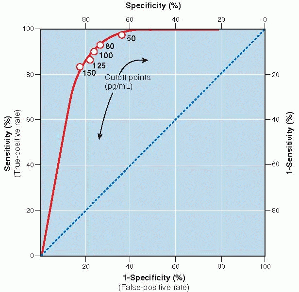

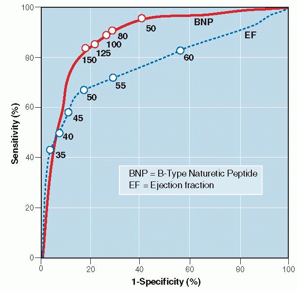

# Assessing the usefulness of a test

## What makes a useful test?

1. The condition/disease that you are testing for is significant
2. There is an effective treatment available & early treatment brings about superior benefits
3. Harms of false positives are small; smaller than the benefits the test delivers

**Analytical validity**

does the test accurately measure what it sets out to measure? (e.g. does a troponin test accurately measure troponin blood levels?)

**Clinical validity**

is what is being measured adequately correlated with an worthwhile clinical outcome? (e.g do troponin levels adequately predict myocardial infarction?)

**Clinical utility**

does use of the test improve patient outcomes? (e.g. does early identification of myocardial infarction with troponin reduce mortality?)

## Benefits and harms of testing

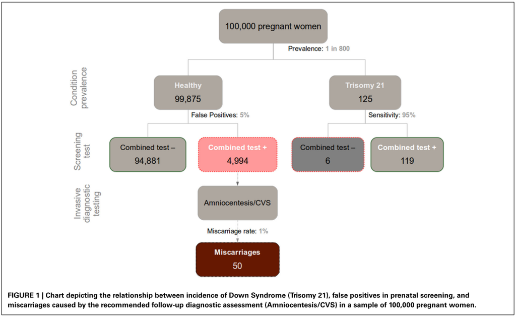

Similar problems can arise in cancer screening. Prasad et al. (2016) and Gigerenzer (2016) note the problems.

- It is hard to identify if screening reduces cancer-specific, cancer-related or overall mortality
- Harms related to false positives tend to be underestimated

## Choosing wisely

> With the complexity of tests, treatments, and procedures available to modern medicine, the challenge is that not all add value. Some are rendered redundant as others take their place. Unnecessary practices are a diversion away from effective care. They often lead to more frequent and invasive investigations that can expose the consumer to undue risk of harm, emotional stress, or financial cost

http://www.choosingwisely.org.au/

- Don’t screen asymptomatic, low-risk patients (< 10% absolute 5-year CV risk) using ECG, stress test, coronary artery calcium score, or carotid artery ultrasound (RACGP)
- Don’t test thyroid function as population screening for asymptomatic patients (RACGP)
- Don’t order chest x-rays in patients with uncomplicated acute bronchitis (RACGP)
- …

## Sources of bias in screening studies

**Self-selection bias**

people who undergo screening can be different to those who do not (they may be healthier, wealthier, etc) and this can effect their disease outcomes

**Lead time bias**

screening may identify disease earlier; this may bring the point of diagnosis earlier making it appear like there is longer survival in those screened even though there is no difference in overall mortality in screened and unscreened individuals

**Length time bias**

screening may selectively identify people who will have the disease for longer (e.g. a long pre-clinical phase in which the condition causes few symptoms but detectable such as some types of prostate cancer)

**Bias due to improved treatment**

if treatment has improved at that same time that screening has been implemented, the benefits of treatment can be mistaken for the benefits of screening

## No easy solutions, but some recommendations

- The required sample size and long lag time between detection and death (or other important outcome) make well-conducted randomized trials impractical in many situations
- Even if you design the ‘in principle’ perfect trial, it will still be subject to some of these biases (e.g. improved treatment, …)

## Recommendations (Gigerenzer, 2016)

- Be aware that **detecting more cancers** and improving **5-year survival rates** doesn’t mean that the screening test improves patient outcomes
- Seek out **cancer-specific mortality** & **overall mortality** (or at least **overall cancer mortality**)
- Clearly and transparently communicate benefits, risks and uncertainties

## References

Fletcher, R. H., Fletcher, S. W., Fletcher, G. S., Fletcher Robert H., (Robert. H., Fletcher, S. W. (Suzanne. W., & Fletcher, G. S. (2014). *Clinical epidemiology the essentials* (5th editio). Wolters Kluwer Health : Lippincott Williams & Wilkins.

Gigerenzer, G. (2016). Full disclosure about cancer screening. *BMJ (Online)*, *352*(January), 1–2. https://doi.org/10.1136/bmj.h6967

Navarrete, G., Correia, R., & Froimovitch, D. (2014). Communicating risk in prenatal screening: The consequences of bayesian misapprehension. *Frontiers in Psychology*, *5*(NOV), 1–4. https://doi.org/10.3389/fpsyg.2014.01272

Prasad, V., Lenzer, J., & Newman, D. H. (2016). Why cancer screening has never been shown to “save lives”—and what we can do about it. *BMJ*, *352*, h6080. https://doi.org/10.1136/bmj.h6080